# Collaborative Movie Recommender

## Implementierung Top-N Metriken

#### Catalog coverage and System-level novelty

Coverage: Summe aller unterschiedlichen Produkte, welche in den Top-N Listen aller Kund*Innen insgesamt auftauchen dividiert durch die Menge aller Produkte. Novelty: Mittel der Shannon Information der Popularität der Produkte in der Top-N Liste gemittelt über alle Kund*Innen.

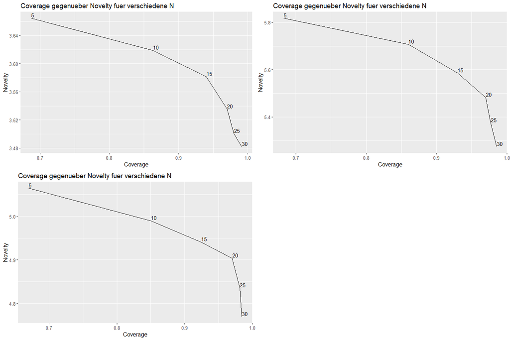

```r
p1 <- coverage_novelty(dense_reduction)
p2 <- coverage_novelty(dense_user_reduction)
p3 <- coverage_novelty(random_reduction)

grid.arrange(p1, p2, p3, ncol = 2, nrow = 2)
```

## Implementierung Top-N Monitor

#### Fixiere 20 zufällig gewählte Testkunden für alle Modellvergleiche

#### Bestimme den Anteil der Top-N Empfehlung nach Genres pro Kunde

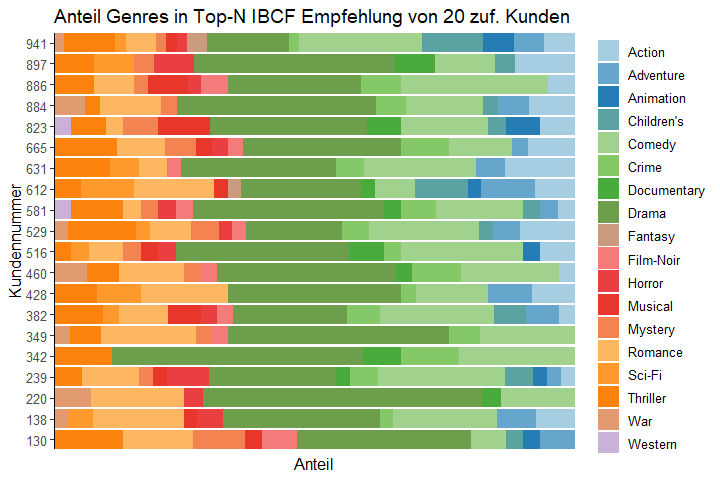

Auf diesem Plot ist die Unterschiedliche Verteilung der Genres in den Top-N Empfehlungen für die verschiedenen Kunden zu sehen. Es fällt auf, dass bei diesem Recommender durchaus verschiedenartige Verteilungen bei den Genres für die verschiednen Nutzer auftreten.

#### Bestimme pro Kunde den Anteil nach Genres seiner Top-Filme (=Filme, welche vom Kunden die besten Bewertungen erhalten haben)

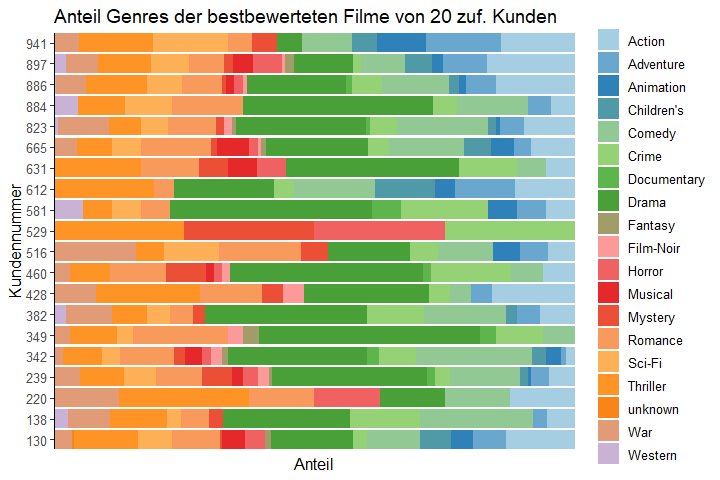

```r
df_user_genres_best <- create_df_user_genres_best(movies, df_user_genres_top_n, genres)
show_genre_fraction_plot(df_user_genres_best, df_user_genres_best$count_best, "Anteil Genres der bestbewerteten Filme von 20 zuf. Kunden")
```

#### Vergleiche pro Kunde Top-Empfehlungen und Top-Filmen nach Genres

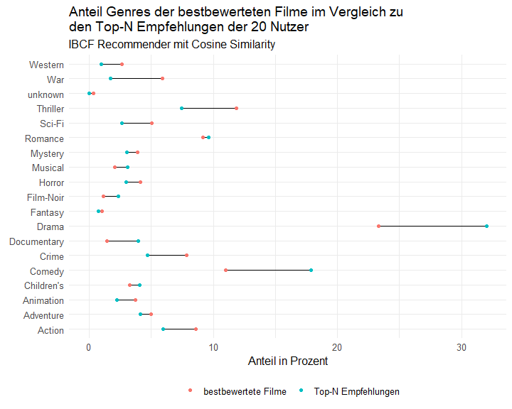

```r
df_user_genres_best <- create_df_user_genres_best(movies, df_user_genres_top_n, genres)

rec <- Recommender(train, method = "IBCF", param=list(method="Cosine", k=30, normalize = NULL, na_as_zero = TRUE))
df_user_genres_top_n <- create_df_user_genres_top_n(rec, genres)
df_user_genres <- create_df_user_genres(df_user_genres_top_n, df_user_genres_best)
show_cleveland_dot_plot(df_user_genres, 'IBCF Recommender mit Cosine Similarity')
```

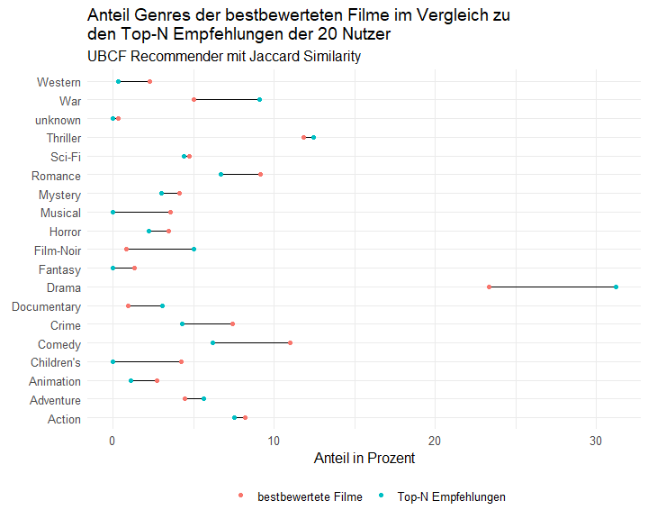

```r
rec <- Recommender(train, method = "UBCF", param=list(method="Jaccard", normalize = NULL))
df_user_genres_top_n <- create_df_user_genres_top_n(rec, genres)
df_user_genres <- create_df_user_genres(df_user_genres_top_n, df_user_genres_best)
show_cleveland_dot_plot(df_user_genres, 'UBCF Recommender mit Jaccard Similarity')
```

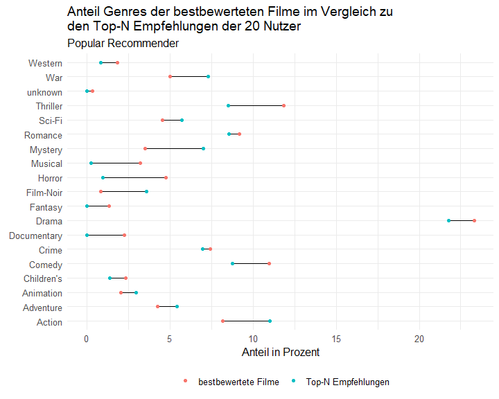

```r
rec <- Recommender(train, method = "POPULAR")
df_user_genres_top_n <- create_df_user_genres_top_n(rec, genres)
df_user_genres <- create_df_user_genres(df_user_genres_top_n, df_user_genres_best)
show_cleveland_dot_plot(df_user_genres, 'Popular Recommender')
```

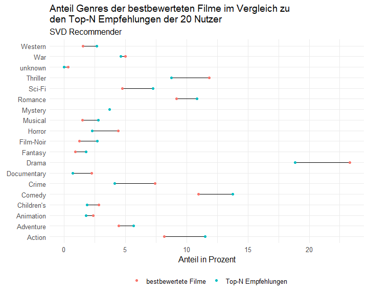

```r
rec <- Recommender(train, method = "SVD")
df_user_genres_top_n <- create_df_user_genres_top_n(rec, genres)
df_user_genres <- create_df_user_genres(df_user_genres_top_n, df_user_genres_best)
show_cleveland_dot_plot(df_user_genres, 'SVD Recommender')
```

Es fällt auf, dass die Genre-Anteile beim SVD-Recommender klar genauer übereinstimmen als beim IBCF Recommender. Jedoch ist es anhand dieser Grafiken sehr schwer den Unterschied der Genauigkeit abzuschätzen. Deshalb definieren wir hier eine Qualitätsmetrik, welche uns erlaubt die Genauigkeit der Genre-Anteile der Verschiedenen Recommender zu vergleichen.

#### Definiere eine Qualitätsmetrik für Top-N Listen und teste sie

Wir haben uns entschieden den mittleren absoluten prozentualen Fehler der Genre-Anteile in den Top-N Empfehlungen auszurechnen. Aber was genau bedeutet das? Nun, zuerst werden die Genre-Anteile der 20 Kunden wie bei den Plots oben zusammengefasst. Danach haben wir die durchschnittliche Abweichung zwischen den Top-N Empfehlungen mit dem jeweiligen Recommender verglichen. Dabei haben wir einen absoluten Wert genutzt, damit sich Fehler nicht ausgleichten. So konnte für jeden Recommender ein einziger Wert ausgerechnet werden. Die Formel dafür sieht dabei folgendermassen aus:

Mittlerer absoluter prozentualer Fehler = abs(Recommender@drama - Top-N@drama) + abs(Recommender@actions - Top-N@action) + …

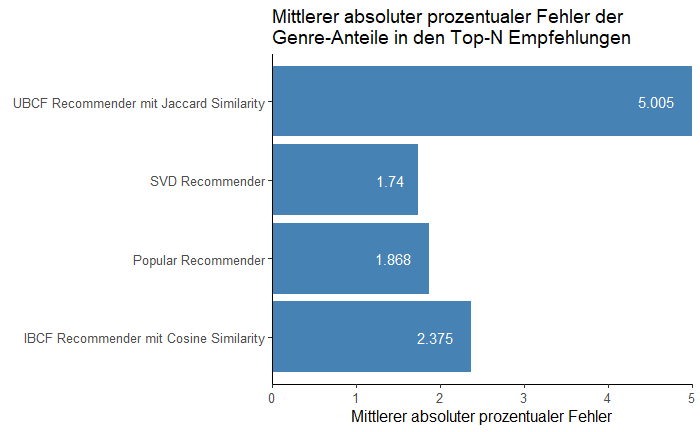

```r
algorithms <- list(
  "IBCF cosine" = list(name="IBCF", param=list(k = 30, method = "cosine", normalize = NULL, na_as_zero = TRUE), desc = 'IBCF Recommender mit Cosine Similarity'),
  "UBCF Jaccard" = list(name="UBCF", param=list(method = "jaccard"), desc = 'UBCF Recommender mit Jaccard Similarity'),
  "Popular" = list(name="POPULAR", param=NULL, desc = 'Popular Recommender'),
  "SVD" = list(name="SVD", param=NULL, desc = 'SVD Recommender')
)

errors <- vector()
algos <- vector()
for (algo in algorithms) {
  rec <- Recommender(train, method = algo$name, param=algo$param)
  df_user_genres_top_n <- create_df_user_genres_top_n(rec, genres)
  df_user_genres <- create_df_user_genres(df_user_genres_top_n, df_user_genres_best)
  error <- compute_mean_absolute_percentage_error(df_user_genres)
  algos <- c(algos, algo$desc)
  errors <- c(errors, error)
}

df_error <- data.frame(description = algos, error = errors)


ggplot(df_error, aes(x=description, y = error)) +
  geom_col(fill = 'steelblue') +
  coord_flip() +
  scale_y_continuous(expand = c(0,0)) +
  geom_text(aes(label=error), hjust=1.5, color = 'white') +
  labs(
    title = "Mittlerer absoluter prozentualer Fehler der \nGenre-Anteile in den Top-N Empfehlungen",
    x = element_blank(),
    y = "Mittlerer absoluter prozentualer Fehler",
    fill = element_blank()
  ) +
  theme_classic() +
  theme(
    text = element_text(size = 12),
    legend.position = 'bottom'
  )
```

Hier sieht man wie zuvor schon vermutet, dass der SVD Recommender am besten abschliesst. Es ist hingegen unklar, warum der UBCF Recommender bei unserer Qualitätsmetrik so viel schlechter abschliesst. Unsere Qualitätsmetrik hat einige kleine Schwachstellen. Theoretisch kann der Recommender bei einigen Nutzern den Anteil stark überschätzen und für einige Nutzer genau das Gegenteil machen. Dies würde dann zu einem guten Score unserer Qualitätsmetrik führen. Auch wurde diese Qualitätsmetrik mit nur 20 Nutzern berechnet, was ebenfalls zu einem grossen Fehler bei der Einschätzung führen kann.